# keyboad-layout

```python
import pandas as pd
import matplotlib.pyplot as plt
plt.rcParams["figure.figsize"] = [10, 6]
%config InlineBackend.figure_format = 'retina'
```

```python
# Pull in the results
df = pd.read_csv('fixed_keyboard_results.csv')
```

The goal is to minimize the amount of movement that needs to be done and thus minimize stress on the body What does the following mean?

- No Movements Needed - No movement needed to type the characters because the finger already should be on the key
- Finger Movements - Need to move the finger before typing a character
- Same Finger Use - Same finger is used to type different letters ("lo" in "hello" with qwerty)

```python
df.style.highlight_min(color = 'lightgreen', axis = 0)
```

|  | RESULTS | No Finger Movements | Finger Movements | Same Finger Usage | Up | Down |
| --- | --- | --- | --- | --- | --- | --- |
| 0 | QWERTY | 2956673 | 7367283 | 580131 | 4235406 | 1339474 |
| 1 | DVORAK | 4849015 | 5474941 | 745183 | 2482259 | 1349158 |
| 2 | WORKMAN | 5176630 | 5147326 | 623122 | 2286812 | 1467445 |
| 3 | HALMAK | 5176630 | 5147326 | 478630 | 2479157 | 2433951 |
| 4 | COLEMAK | 5697798 | 4626158 | 289366 | 1861126 | 1339474 |
| 5 | COLEMAK DH | 5697798 | 4626158 | 347441 | 1861126 | 1116931 |
| 6 | ENGRAM | 5060163 | 5263793 | 581576 | 2732761 | 2531032 |
| 7 | NORMAN | 5176630 | 5147326 | 708291 | 2233339 | 1339474 |
| 8 | CARPLAX | 4895205 | 5428751 | 510712 | 1940140 | 1456706 |
| 9 | RSTLNE | 5697798 | 4626158 | 485628 | 2551998 | 1204866 |

You can see above that QWERTY wins very few tests and one of them is the only one that you are supposed to have the highest on.

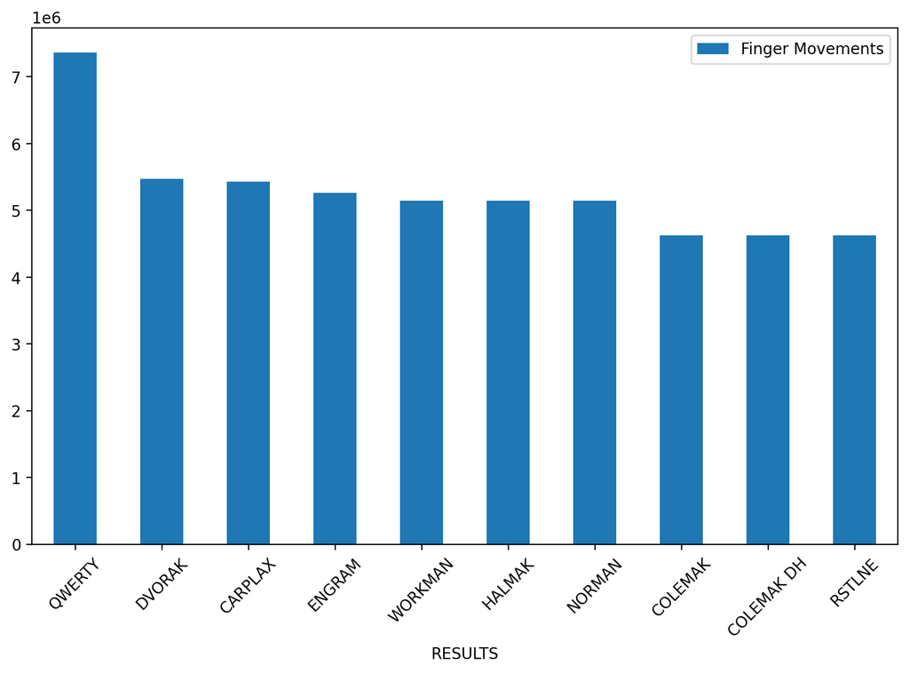

```python
ax = df.sort_values(by='Finger Movements', ascending=False).plot(kind='bar', x='RESULTS', y='Finger Movements')
plt.xticks(rotation=45)
plt.show()
```

The chart above shows the required finger movements to type everything in our Python data set. We can see that QWERTY requires a lot more movement which means more work and strain on your fingers, joints, and wrists. Anything is better than QWERTY, but the versions of Colemak are clearly the winners here.

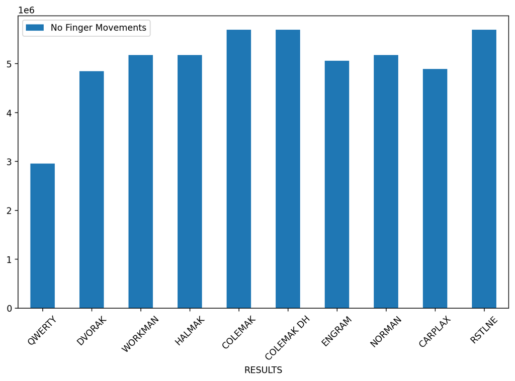

```python
ax = df.plot(kind='bar', x='RESULTS', y='No Finger Movements')
plt.xticks(rotation=45)
plt.show()
```

In this chart we want the opposite. We want to know what layout allows us to type lots of words without having to move your fingers. Honestly, its basically the opposite of the version previous.

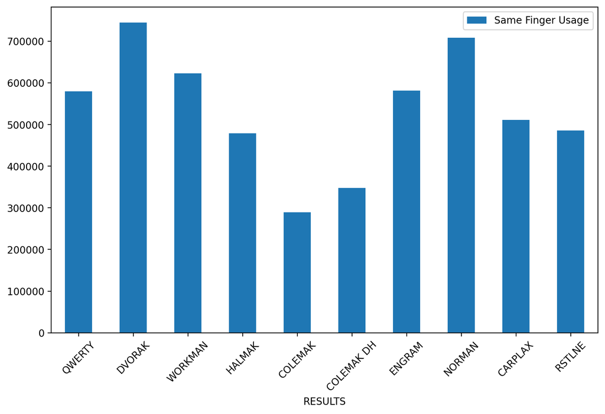

```python
ax = df.plot(kind='bar', x='RESULTS', y='Same Finger Usage')
plt.xticks(rotation=45)
plt.show()
```

The stat for Same Finger Usage we want low as well. The idea is to share the load between all the fingers and not just strain one or two. Its a case in good delegation. Again we see that Colemak works best for my needs.